# Práctica 2: El problema de regresión lineal

En esta práctica estudiaremos el problema de regresión lineal bajo la óptica de la optimización no lineal.

## 2.1. Regresión lineal paso a paso (from scratch)

```python
import numpy as np
```

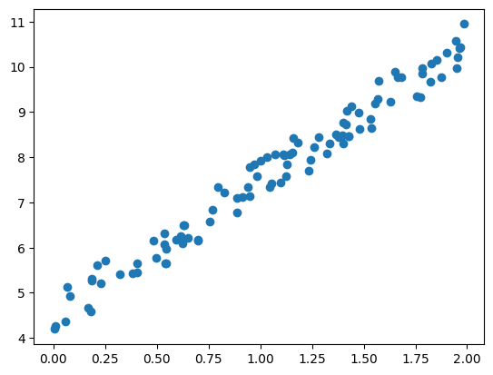

```python
# Generamos 100 instances con una sóla característica en el intervalo (0, 2)

X = 2 * np.random.rand(100, 1)

# Generamos 100 labels

y = 4 + 3 * X + np.random.rand(100, 1)

# dibujamos los datos generados

import matplotlib.pyplot as plt

plt.scatter(X, y)

plt.show()
```

Resolvemos el problema de regresión lineal

$$ \text{Minimizar en } \theta : \quad MSE (\theta) = \frac{1}{m}\sum_{i=1}^{m}\left(\theta^T x^{(i)} - y^{(i)}\right)^2. $$

donde $x^{(i)}$ es la fila i-ésima de $X$ e $y^{(i)}$ la componente i-ésima del vector de labels $Y$.

El sistema de optimalidad asociado es $$X^TX \theta = X^T Y$$ cuya solución $\theta_{\text{best}}$ viene dada por

$$ \theta_{\text{best}} = (X^TX)^{-1} X^T Y . $$

```python
# Procedemos con la optimización
# Resolvemos la condición de optimalidad.
# Antes de nada añadimos la columna de unos para el bias

X_b = np.c_[np.ones((100, 1)), X]

# Ahora sí resolvemos la condición de optimalidad

theta_best = np.linalg.inv(X_b.T.dot(X_b)).dot(X_b.T).dot(y)

print(f"theta_best = {theta_best}")
```

```
theta_best = [[4.45624907]
 [3.01033864]]
```

Una vez hemos calculado el bias y el peso óptimos, definimos el modelo de predicción

```python
def model_predict(x):
    y_hat = theta_best[0] + x * theta_best[1]
    return y_hat
```

Finalmente, dibujamos de nuevos los datos junto con el modelo de predicción

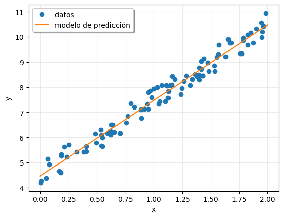

```python
plt.plot(X, y, 'o', label='datos')
x = np.linspace(0, 2, 100)
y_predict = model_predict(x)
plt.plot(x, y_predict, label='modelo de predicción')
plt.xlabel('x')
plt.ylabel('y')
plt.legend(framealpha=1, shadow=True)
plt.grid(alpha=0.25)
plt.show()
```

## 2.2. Regresión lineal a través de algunos módulos de Python

Debido al intenso uso que se hace en Ciencia de Datos de la regresión lineal, ésta aparece implementada en varios módulos de Python. Veamos algunos de ellos.

### 2.2.1. Ajuste de mínimos cuadrados en Numpy

```python
theta_best_svd, residuals, rank, s = np.linalg.lstsq(X_b.T.dot(X_b), X_b.T.dot(y), rcond=1e-6)

print(f"theta_best_svd =  {theta_best_svd}")

# rcond es el umbral para eliminar los valores singulares con valor menor que recond.
# véase la API para los detalles del resto de outputs.
```

```
theta_best_svd =  [[4.45624907]
 [3.01033864]]
```

```python
print(f"theta_best_pinv = {np.linalg.pinv(X_b.T.dot(X_b)).dot(X_b.T).dot(y)}")
```

```
theta_best_pinv = [[4.45624907]
 [3.01033864]]
```

### 2.2.2. Regresión lineal en el módulo scikit-learn

En la API siguiente están los detalles [linear_model](https://scikit-learn.org/stable/modules/linear_model.html)

Veamos un ejemplo en dimensión grande

```python
from sklearn.datasets import make_regression
# definimos el conjunto de datos de entrenamiento con 1000 muestras y 10 características
X_train, y_train = make_regression(n_samples=1000, n_features=10)

#X_train, y_train = make_regression(n_samples=1000, n_features=10, n_informative=10, noise=0.2,
#random_state=1)
# veamos la forma del conjunto de datos
print(X_train.shape, y_train.shape)
```

```
(1000, 10) (1000,)
```

```python
# construimos el modelo de predicción lineal
from sklearn import linear_model

# Modelo de regresión lineal
regr = linear_model.LinearRegression()
```

```python
# Calculamos los pesos y bias (coeficientes) a partir de los datos de entrenamiento
regr.fit(X_train, y_train)
# Los coeficientes
print(f"Coeficientes = \n {regr.coef_}")
```

```
Coeficientes =
 [22.14880703 97.25994216 30.61298333 82.82863096 24.12826872 74.68591699
 72.49567817 82.6024545  90.24146906 69.97842418]
```

La optimización acaba aquí. Lo que sigue es Estadística y Machine Learning. Aún así, indicamos cómo habría que continuar:

A partir de los coeficificientes anteriores se pueden hacer predicciones usando un nuevo conjunto de datos test. Para ello se usa el método regr.predict(X_test)

X_test es el conjunto de datos sobre el que se quieren hacer predicciones

La bondad del modelo (es decir el error cuadrático medio) se chequea con el método mean_squared_error(y_test, y_pred))

y_test son datos que hay que proporcionar